# Buy Online Pick Up in Store (BOPS)

Kevin, Ram, Ryo

June 6, 2017

# Visualization of Variables

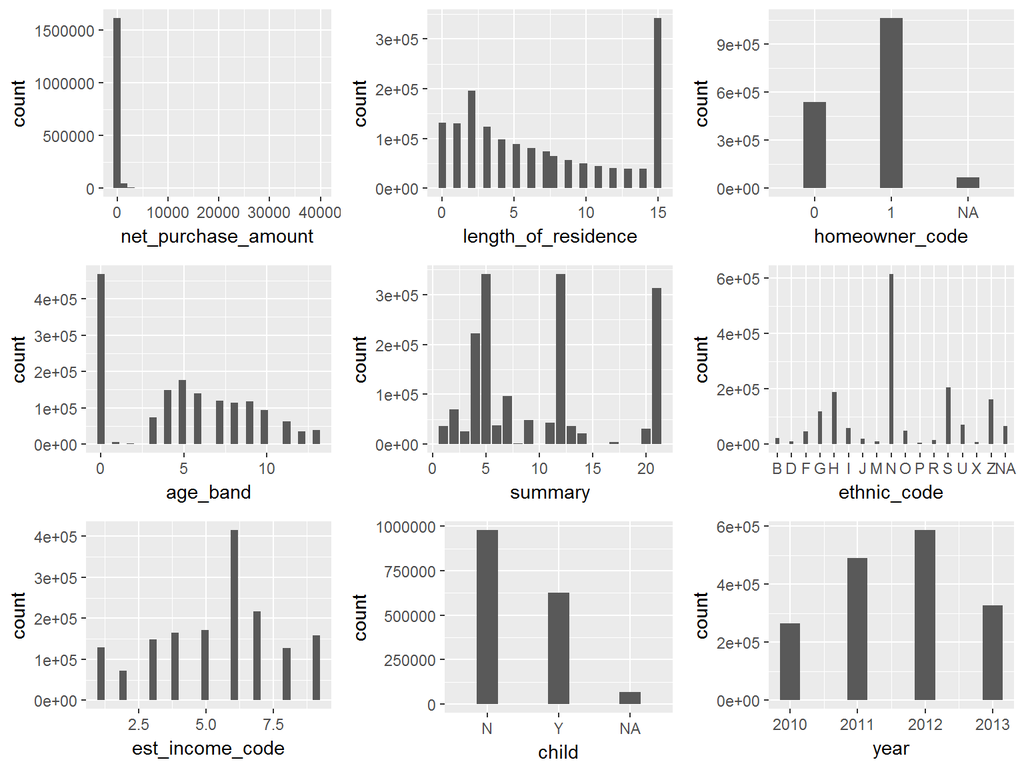

# Goal 1: Store Sales

**Purpose**: Assess the impact of the BOPS strategy on store sales

**Primary Independent Variable**: BOPS (dummy variable)  
0 - mail  
1 - store pickup

**Secondary Independent Variable**: Store Number  
As the purpose states, we want to assess impact at the store level.

**Control Variables**:  
log(net_puchase_amount)*  
gender  
age_band  
est_income_code  
ethnic_code

**Dependent Variable**: Transaction Count (generated variable)  
* Why is net_purchase_amount not a sufficient dependent variable?  
Will look at the program 1 year before and 1 year after the start.

**Unused Variables**:  
transaction_id  
customer_id  
purchase_date  
sku  
return_date  
return_store  
time_to_return  
homeowner_code  
length_of_residence  
child  
year  
month_index  
summary

# Data Cleaning for sales model

## Filter out customers with only 1 transaction

We are primarily concerned with return customers and not one time only customers.

```
## From our original set of 1775998 data points, we are left with 169334 data points.
```

## Data points that are missing information

```
##
##      0      1      4      6
## 164094     13    183   5044
```

Confirm that we will not lose too much data due to NA.

## net_purchase_amount (log)

```
## Number of na entries: 0
```

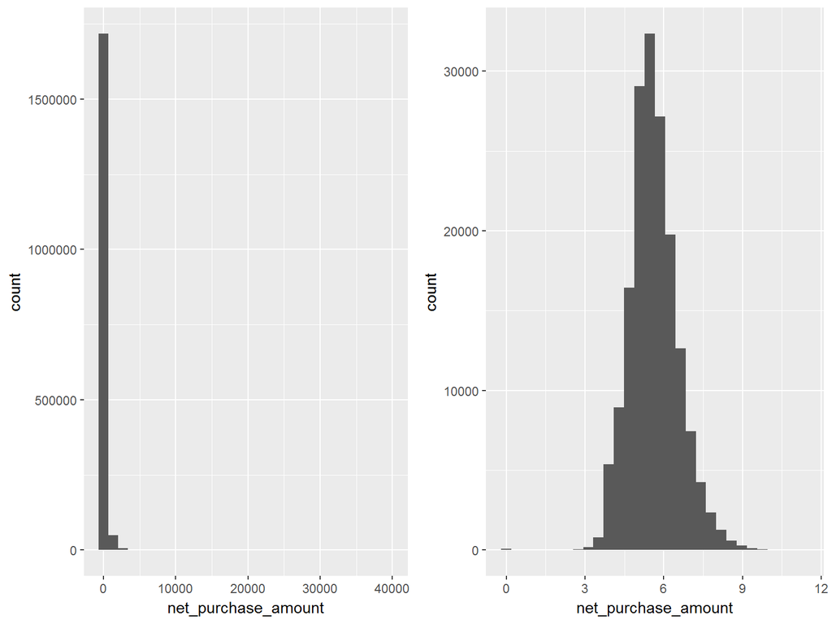

# Sales Model 1 OLS (2+ items purchased)

```
##
## Call:
## lm(formula = numitems ~ bops + store_number + net_purchase_amount +
##     gender + age_band + est_income_code + ethnic_code, data = bops3)
##
## Residuals:
##     Min      1Q  Median      3Q     Max
##  -10.26   -1.41   -0.43    0.62 1461.26
##
## Coefficients:
##                      Estimate Std. Error t value Pr(>|t|)
## (Intercept)         -5.190738   0.196415 -26.427  < 2e-16 ***
## bops                 1.992084   0.064011  31.121  < 2e-16 ***
## store_number2       -0.206868   0.064949  -3.185  0.00145 **
## net_purchase_amount  1.536274   0.019415  79.130  < 2e-16 ***
## genderM             -0.821311   0.037974 -21.628  < 2e-16 ***
## genderU             -0.130597   0.068648  -1.902  0.05712 .
## age_band             0.011504   0.004999   2.301  0.02139 *
## est_income_code      0.047726   0.008227   5.801 6.61e-09 ***
## ethnic_codeD         0.331676   0.274350   1.209  0.22668
## ethnic_codeF        -0.271764   0.176822  -1.537  0.12431
## ethnic_codeG        -0.119364   0.157119  -0.760  0.44743
## ethnic_codeH        -0.055694   0.151220  -0.368  0.71265
## ethnic_codeI        -0.026914   0.170629  -0.158  0.87467
## ethnic_codeJ         0.071868   0.211767   0.339  0.73433
## ethnic_codeM        -0.319014   0.264743  -1.205  0.22821
## ethnic_codeN        -0.102334   0.144881  -0.706  0.47998
## ethnic_codeO         0.547696   0.173867   3.150  0.00163 **
## ethnic_codeP        -0.200782   0.320044  -0.627  0.53043
## ethnic_codeR        -0.034643   0.229423  -0.151  0.87997
## ethnic_codeS        -0.156460   0.150679  -1.038  0.29910
## ethnic_codeU        -0.038679   0.163990  -0.236  0.81354
## ethnic_codeX        -0.305930   0.301752  -1.014  0.31066
## ethnic_codeZ        -0.016054   0.152228  -0.105  0.91601
## ---
## Signif. codes:  0 '***' 0.001 '**' 0.01 '*' 0.05 '.' 0.1 ' ' 1
##
## Residual standard error: 7.239 on 163996 degrees of freedom
##   (607 observations deleted due to missingness)
## Multiple R-squared:  0.04453,    Adjusted R-squared:  0.0444
## F-statistic: 347.4 on 22 and 163996 DF,  p-value: < 2.2e-16
```

# Sales Model with Interaction (2+ items purchased)

We want to see the effect on stores.

```
##
## Call:
## lm(formula = numitems ~ bops * store_number + net_purchase_amount +
##     gender + age_band + est_income_code + ethnic_code, data = bops3)
##
## Residuals:
##     Min      1Q  Median      3Q     Max
##  -10.33   -1.41   -0.42    0.62 1461.27
##
## Coefficients:
##                      Estimate Std. Error t value Pr(>|t|)
## (Intercept)         -5.124986   0.196931 -26.024  < 2e-16 ***
## bops                 0.764406   0.276591   2.764  0.00572 **
## store_number2       -0.277992   0.066790  -4.162 3.15e-05 ***
## net_purchase_amount  1.536587   0.019414  79.150  < 2e-16 ***
## genderM             -0.822096   0.037972 -21.650  < 2e-16 ***
## genderU             -0.131516   0.068645  -1.916  0.05538 .
## age_band             0.011405   0.004999   2.281  0.02253 *
## est_income_code      0.047288   0.008227   5.748 9.07e-09 ***
## ethnic_codeD         0.329680   0.274334   1.202  0.22946
## ethnic_codeF        -0.271978   0.176811  -1.538  0.12399
## ethnic_codeG        -0.119163   0.157109  -0.758  0.44817
## ethnic_codeH        -0.052651   0.151212  -0.348  0.72770
## ethnic_codeI        -0.026688   0.170619  -0.156  0.87570
## ethnic_codeJ         0.072136   0.211754   0.341  0.73336
## ethnic_codeM        -0.317994   0.264727  -1.201  0.22967
## ethnic_codeN        -0.101513   0.144873  -0.701  0.48349
## ethnic_codeO         0.547317   0.173857   3.148  0.00164 **
## ethnic_codeP        -0.200124   0.320024  -0.625  0.53175
## ethnic_codeR        -0.036684   0.229409  -0.160  0.87296
## ethnic_codeS        -0.155627   0.150670  -1.033  0.30165
## ethnic_codeU        -0.038129   0.163981  -0.233  0.81613
## ethnic_codeX        -0.305249   0.301734  -1.012  0.31171
## ethnic_codeZ        -0.015751   0.152219  -0.103  0.91758
## bops:store_number2   1.296598   0.284188   4.562 5.06e-06 ***
## ---
## Signif. codes:  0 '***' 0.001 '**' 0.01 '*' 0.05 '.' 0.1 ' ' 1
##
## Residual standard error: 7.239 on 163995 degrees of freedom
##   (607 observations deleted due to missingness)
## Multiple R-squared:  0.04465,    Adjusted R-squared:  0.04452
## F-statistic: 333.3 on 23 and 163995 DF,  p-value: < 2.2e-16
```

## Comparison of the two models (nested)

```
## Analysis of Variance Table
##
## Model 1: numitems ~ bops + store_number + net_purchase_amount + gender +
##     age_band + est_income_code + ethnic_code
## Model 2: numitems ~ bops * store_number + net_purchase_amount + gender +
##     age_band + est_income_code + ethnic_code
##   Res.Df     RSS Df Sum of Sq  Pr(>Chi)
## 1 163996 8594095
## 2 163995 8593004  1    1090.7 5.056e-06 ***
## ---
## Signif. codes:  0 '***' 0.001 '**' 0.01 '*' 0.05 '.' 0.1 ' ' 1
```

# Poisson

```
##
## Call:
## glm(formula = numitems ~ bops * store_number + net_purchase_amount +
##     gender + age_band + est_income_code + ethnic_code, family = "poisson",
##     data = bops3)
##
## Deviance Residuals:
##    Min      1Q  Median      3Q     Max
## -7.034  -0.650  -0.203   0.287  88.758
##
## Coefficients:
##                       Estimate Std. Error z value Pr(>|z|)
## (Intercept)         -1.1775150  0.0145657 -80.842  < 2e-16 ***
## bops                 0.1920622  0.0188655  10.181  < 2e-16 ***
## store_number2       -0.0875733  0.0051448 -17.022  < 2e-16 ***
## net_purchase_amount  0.4173110  0.0013226 315.535  < 2e-16 ***
## genderM             -0.2386535  0.0029131 -81.925  < 2e-16 ***
## genderU             -0.0393560  0.0050355  -7.816 5.46e-15 ***
## age_band             0.0032856  0.0003797   8.652  < 2e-16 ***
## est_income_code      0.0134136  0.0006266  21.406  < 2e-16 ***
## ethnic_codeD         0.0868549  0.0193523   4.488 7.19e-06 ***
## ethnic_codeF        -0.0743398  0.0133365  -5.574 2.49e-08 ***
## ethnic_codeG        -0.0260387  0.0116794  -2.229 0.025783 *
## ethnic_codeH        -0.0006448  0.0111666  -0.058 0.953950
## ethnic_codeI         0.0126582  0.0126705   0.999 0.317779
## ethnic_codeJ         0.0245933  0.0156115   1.575 0.115180
## ethnic_codeM        -0.0761898  0.0205588  -3.706 0.000211 ***
## ethnic_codeN        -0.0183826  0.0106800  -1.721 0.085213 .
## ethnic_codeO         0.1372565  0.0125447  10.941  < 2e-16 ***
## ethnic_codeP        -0.0364407  0.0237662  -1.533 0.125201
## ethnic_codeR        -0.0117417  0.0167414  -0.701 0.483081
## ethnic_codeS        -0.0353540  0.0111561  -3.169 0.001530 **
## ethnic_codeU        -0.0033079  0.0121324  -0.273 0.785120
## ethnic_codeX        -0.0830971  0.0234896  -3.538 0.000404 ***
## ethnic_codeZ         0.0052827  0.0112369   0.470 0.638272
## bops:store_number2   0.2925482  0.0192934  15.163  < 2e-16 ***
## ---
## Signif. codes:  0 '***' 0.001 '**' 0.01 '*' 0.05 '.' 0.1 ' ' 1
##
## (Dispersion parameter for poisson family taken to be 1)
##
##     Null deviance: 381101  on 164018  degrees of freedom
## Residual deviance: 268946  on 163995  degrees of freedom
##   (607 observations deleted due to missingness)
## AIC: 744118
##
## Number of Fisher Scoring iterations: 5
```

## Heteroscedasticity test and IRRs

```
##
##  Goldfeld-Quandt test
##
## data:  poisson1
## GQ = 1.5494, df1 = 81986, df2 = 81985, p-value < 2.2e-16
## alternative hypothesis: variance increases from segment 1 to 2
```

```
##
##  studentized Breusch-Pagan test
##
## data:  poisson1
## BP = 310.57, df = 23, p-value < 2.2e-16
```

Both tests are significant therefore we have heteroscedasticity.

## Huber-White robust standard errors

```
##                          Orig Est Pr(>|z|) Std Errors Est Pr(>|z|)
## (Intercept)         -1.1775149516      ***  -1.1775149516      ***
## bops                 0.1920621686      ***   0.1920621686      ***
## store_number2       -0.0875733460      ***  -0.0875733460      ***
## net_purchase_amount  0.4173110272      ***   0.4173110272      ***
## genderM             -0.2386535399      ***  -0.2386535399      ***
## genderU             -0.0393560321      ***  -0.0393560321
## age_band             0.0032856403      ***   0.0032856403      ***
## est_income_code      0.0134136238      ***   0.0134136238      ***
## ethnic_codeD         0.0868548649      ***   0.0868548649
## ethnic_codeF        -0.0743397866      ***  -0.0743397866      ***
## ethnic_codeG        -0.0260386918      ***  -0.0260386918
## ethnic_codeH        -0.0006448463           -0.0006448463
## ethnic_codeI         0.0126582192            0.0126582192
## ethnic_codeJ         0.0245932770            0.0245932770
## ethnic_codeM        -0.0761897998      ***  -0.0761897998
## ethnic_codeN        -0.0183825554           -0.0183825554
## ethnic_codeO         0.1372565235      ***   0.1372565235
## ethnic_codeP        -0.0364407348           -0.0364407348
## ethnic_codeR        -0.0117416929           -0.0117416929
## ethnic_codeS        -0.0353539808      ***  -0.0353539808
## ethnic_codeU        -0.0033079427           -0.0033079427
## ethnic_codeX        -0.0830971059      ***  -0.0830971059
## ethnic_codeZ         0.0052826615            0.0052826615
## bops:store_number2   0.2925482101      ***   0.2925482101      ***
```

bops and store number are still significant.

```
##         (Intercept)                bops       store_number2
##           0.3080433           1.2117458           0.9161517
## net_purchase_amount             genderM             genderU
##           1.5178745           0.7876877           0.9614084
##            age_band     est_income_code        ethnic_codeD
##           1.0032910           1.0135040           1.0907384
##        ethnic_codeF        ethnic_codeG        ethnic_codeH
##           0.9283562           0.9742974           0.9993554
##        ethnic_codeI        ethnic_codeJ        ethnic_codeM
##           1.0127387           1.0248982           0.9266403
##        ethnic_codeN        ethnic_codeO        ethnic_codeP
##           0.9817854           1.1471224           0.9642152
##        ethnic_codeR        ethnic_codeS        ethnic_codeU
##           0.9883270           0.9652637           0.9966975
##        ethnic_codeX        ethnic_codeZ  bops:store_number2
##           0.9202618           1.0052966           1.3398373
```

## Model fit test

```
## Chi-squared test statistic: 112154.9
```

```
## Degrees of freedom: 23
```

```
## P value: 0
```

# Negative Binomial model

```
##
## Call:
## glm.nb(formula = numitems ~ bops * store_number + net_purchase_amount +
##     gender + age_band + est_income_code + ethnic_code, data = bops3,
##     init.theta = 6.308732896, link = log)
##
## Deviance Residuals:
##     Min       1Q   Median       3Q      Max
## -3.3101  -0.5355  -0.2141   0.1732  24.7764
##
## Coefficients:
##                       Estimate Std. Error z value Pr(>|z|)
## (Intercept)         -0.7819438  0.0187161 -41.779  < 2e-16 ***
## bops                 0.1897811  0.0247169   7.678 1.61e-14 ***
## store_number2       -0.0740964  0.0064077 -11.564  < 2e-16 ***
## net_purchase_amount  0.3510549  0.0017954 195.529  < 2e-16 ***
## genderM             -0.2162695  0.0036491 -59.267  < 2e-16 ***
## genderU             -0.0640389  0.0064850  -9.875  < 2e-16 ***
## age_band             0.0039543  0.0004784   8.267  < 2e-16 ***
## est_income_code      0.0099594  0.0007884  12.633  < 2e-16 ***
## ethnic_codeD         0.0351137  0.0254871   1.378 0.168295
## ethnic_codeF        -0.0641894  0.0168629  -3.807 0.000141 ***
## ethnic_codeG        -0.0314619  0.0148865  -2.113 0.034563 *
## ethnic_codeH         0.0019933  0.0142723   0.140 0.888925
## ethnic_codeI        -0.0060704  0.0161550  -0.376 0.707094
## ethnic_codeJ         0.0023499  0.0200170   0.117 0.906548
## ethnic_codeM        -0.0639731  0.0255471  -2.504 0.012275 *
## ethnic_codeN        -0.0259532  0.0136713  -1.898 0.057646 .
## ethnic_codeO         0.0763046  0.0162934   4.683 2.82e-06 ***
## ethnic_codeP        -0.0238458  0.0301230  -0.792 0.428586
## ethnic_codeR        -0.0028167  0.0215072  -0.131 0.895803
## ethnic_codeS        -0.0388530  0.0142480  -2.727 0.006393 **
## ethnic_codeU        -0.0074653  0.0154960  -0.482 0.629979
## ethnic_codeX        -0.0570445  0.0291295  -1.958 0.050194 .
## ethnic_codeZ         0.0053944  0.0143655   0.376 0.707282
## bops:store_number2   0.2243099  0.0253457   8.850  < 2e-16 ***
## ---
## Signif. codes:  0 '***' 0.001 '**' 0.01 '*' 0.05 '.' 0.1 ' ' 1
##
## (Dispersion parameter for Negative Binomial(6.3087) family taken to be 1)
##
##     Null deviance: 170869  on 164018  degrees of freedom
## Residual deviance: 112143  on 163995  degrees of freedom
##   (607 observations deleted due to missingness)
## AIC: 651247
##
## Number of Fisher Scoring iterations: 1
##
##
##               Theta:  6.3087
##           Std. Err.:  0.0450
##
##  2 x log-likelihood:  -651197.2450
```

## Heteroscedasticity

```
##
##  Goldfeld-Quandt test
##
## data:  negbin1
## GQ = 1.5494, df1 = 81986, df2 = 81985, p-value < 2.2e-16
## alternative hypothesis: variance increases from segment 1 to 2
```

```
##
##  studentized Breusch-Pagan test
##
## data:  negbin1
## BP = 310.57, df = 23, p-value < 2.2e-16
```

```
##                         Orig Est Pr(>|z|) Std Errors Est Pr(>|z|)
## (Intercept)         -0.781943780      ***   -0.781943780      ***
## bops                 0.189781122      ***    0.189781122      ***
## store_number2       -0.074096358      ***   -0.074096358      ***
## net_purchase_amount  0.351054896      ***    0.351054896      ***
## genderM             -0.216269524      ***   -0.216269524      ***
## genderU             -0.064038938      ***   -0.064038938      ***
## age_band             0.003954340      ***    0.003954340      ***
## est_income_code      0.009959396      ***    0.009959396      ***
## ethnic_codeD         0.035113676             0.035113676
## ethnic_codeF        -0.064189351      ***   -0.064189351      ***
## ethnic_codeG        -0.031461866      ***   -0.031461866
## ethnic_codeH         0.001993330             0.001993330
## ethnic_codeI        -0.006070417            -0.006070417
## ethnic_codeJ         0.002349876             0.002349876
## ethnic_codeM        -0.063973139      ***   -0.063973139      ***
## ethnic_codeN        -0.025953237            -0.025953237
## ethnic_codeO         0.076304610      ***    0.076304610      ***
## ethnic_codeP        -0.023845768            -0.023845768
## ethnic_codeR        -0.002816680            -0.002816680
## ethnic_codeS        -0.038852960      ***   -0.038852960
## ethnic_codeU        -0.007465317            -0.007465317
## ethnic_codeX        -0.057044518            -0.057044518
## ethnic_codeZ         0.005394369             0.005394369
## bops:store_number2   0.224309948      ***    0.224309948      ***
```

## Test model fit

```
## Chi-squared test statistic: 58725.7
```

```
## Degrees of freedom: 23
```

```
## P value: 0
```

Model fits the data since the test is significant

## Compare Poisson regression to Negative Binomial regression

Chisq Test

```
## 'log Lik.' 92872.51 (df=25)
```

```
## 'log Lik.' 0 (df=25)
```

Negative Binomial is more appropriate than Poisson since there is over-dispersion.

# Sales Model Summary

Final Model: Negative Binomial numitems ~ bops * store_number + net_purchase_amount + gender + age_band + est_income_code + ethnic_code

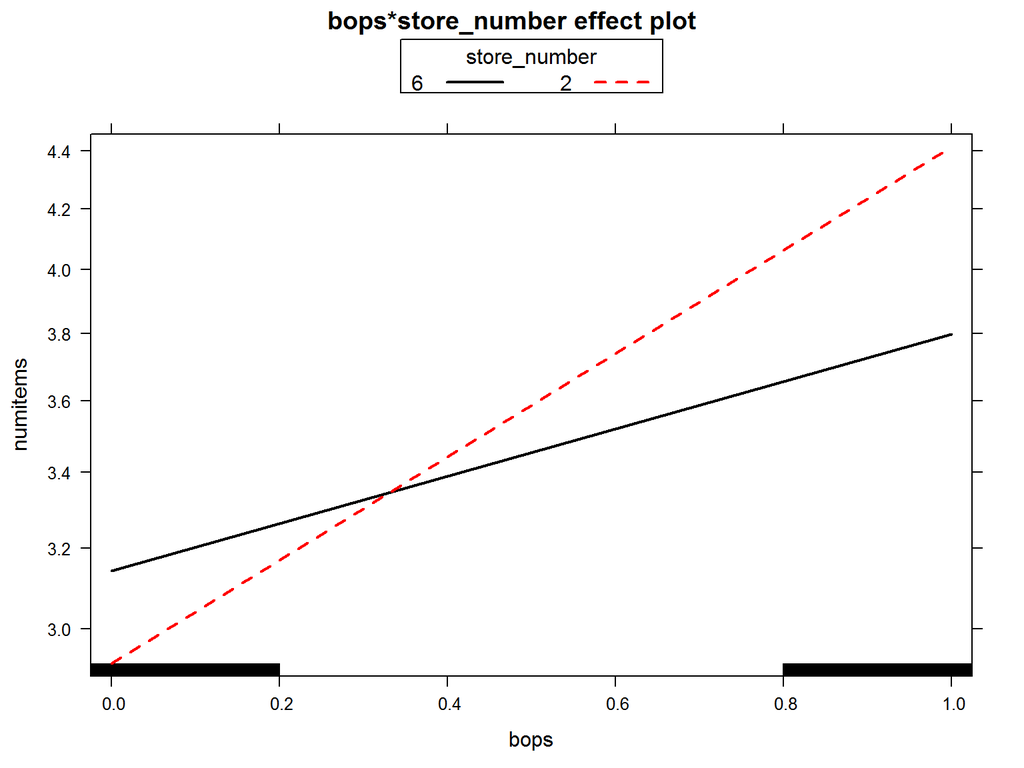

Sales Increase

|  | Mean Transaction Price | Number of Customer | Transaction Increase | Total Sales Increase |
| --- | --- | --- | --- | --- |
| 2 | $170 | 75,000 | 1.5 | $19,125,000 |
| 6 | $146 | 6,500 | 0.6 | $569,400 |

# Goal 2: Store Returns

**Purpose**: Assess the impact of the BOPS strategy on store returns

**Dependent Variable**: return (dummy variable)  
0 - Item has not been returned  
1 - Item has been returned

**Primary Independent Variable**: BOPS (dummy variable)  
0 - mail  
1 - store pickup

**Secondary Independent Variable**: Store Number  
As the purpose states, we want to assess impact at the store level.

**Control Variables**:  
log(net_puchase_amount)  
gender  
age_band  
est_income_code  
ethnic_code  
month  
summary *

# Data Cleaning for returns model

## Data points that are missing information

```
##
##       0       1       4       5       6
## 1692283    5789    2836      10   75080
```

## net_purchase_amount (log)

```
## Number of na entries: 0
```

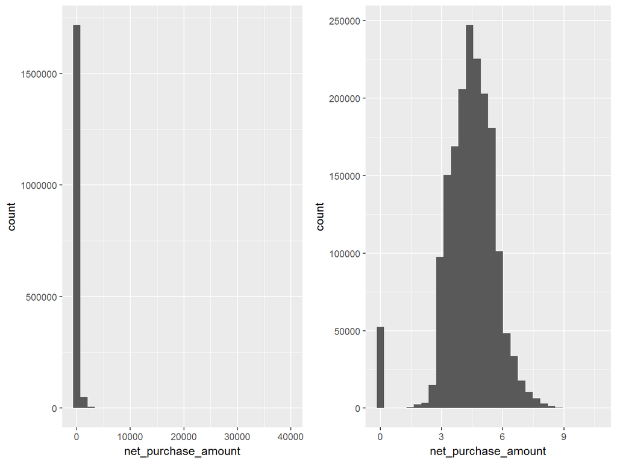

# Returns Model 1 OLS

```
##
## Call:
## lm(formula = return ~ bops + store_number + net_purchase_amount +
##     gender + age_band + est_income_code + ethnic_code + month +
##     summary, data = returns1)
##
## Residuals:
##      Min       1Q   Median       3Q      Max
## -0.35955 -0.12146 -0.09067 -0.05789  1.02448
##
## Coefficients:
##                       Estimate Std. Error t value Pr(>|t|)
## (Intercept)         -1.406e-02  9.796e-03  -1.435 0.151297
## bops                 1.767e-02  5.902e-04  29.937  < 2e-16 ***
## store_number2        7.121e-02  9.296e-03   7.661 1.85e-14 ***
## store_number6        6.714e-02  9.337e-03   7.191 6.45e-13 ***
## net_purchase_amount  2.917e-02  2.331e-04 125.115  < 2e-16 ***
## genderM             -2.952e-02  5.032e-04 -58.678  < 2e-16 ***
## genderU             -2.081e-02  8.210e-04 -25.350  < 2e-16 ***
## age_band            -2.561e-04  6.416e-05  -3.991 6.58e-05 ***
## est_income_code      1.886e-03  1.055e-04  17.878  < 2e-16 ***
## ethnic_codeD        -2.057e-02  3.553e-03  -5.791 6.99e-09 ***
## ethnic_codeF        -4.569e-02  2.364e-03 -19.323  < 2e-16 ***
## ethnic_codeG        -5.447e-02  2.119e-03 -25.702  < 2e-16 ***
## ethnic_codeH        -5.119e-02  2.054e-03 -24.915  < 2e-16 ***
## ethnic_codeI        -4.388e-02  2.285e-03 -19.201  < 2e-16 ***
## ethnic_codeJ        -3.598e-02  2.792e-03 -12.886  < 2e-16 ***
## ethnic_codeM        -6.051e-02  3.474e-03 -17.419  < 2e-16 ***
## ethnic_codeN        -5.454e-02  1.979e-03 -27.562  < 2e-16 ***
## ethnic_codeO        -1.094e-02  2.344e-03  -4.667 3.05e-06 ***
## ethnic_codeP        -5.149e-02  4.245e-03 -12.128  < 2e-16 ***
## ethnic_codeR        -2.323e-02  3.077e-03  -7.548 4.41e-14 ***
## ethnic_codeS        -5.182e-02  2.048e-03 -25.305  < 2e-16 ***
## ethnic_codeU        -3.948e-02  2.226e-03 -17.736  < 2e-16 ***
## ethnic_codeX        -5.500e-02  4.013e-03 -13.706  < 2e-16 ***
## ethnic_codeZ        -3.826e-02  2.076e-03 -18.429  < 2e-16 ***
## monthAUG             5.311e-03  1.379e-03   3.851 0.000117 ***
## monthDEC            -1.257e-02  1.038e-03 -12.110  < 2e-16 ***
## monthFEB            -7.784e-03  1.160e-03  -6.710 1.95e-11 ***
## monthJAN             2.051e-02  1.236e-03  16.592  < 2e-16 ***
```

[output cut: 16 more lines]

```
## summary11           -4.088e-02  2.186e-03 -18.706  < 2e-16 ***
## summary12           -4.283e-02  1.737e-03 -24.651  < 2e-16 ***
## summary13           -4.233e-02  2.262e-03 -18.716  < 2e-16 ***
## summary14           -1.064e-02  2.632e-03  -4.042 5.31e-05 ***
## summary15           -2.372e-02  5.444e-02  -0.436 0.663028
## summary17           -3.091e-02  4.955e-03  -6.238 4.42e-10 ***
## summary20            3.662e-02  2.335e-03  15.681  < 2e-16 ***
## summary21           -3.957e-02  1.752e-03 -22.584  < 2e-16 ***
## ---
## Signif. codes:  0 '***' 0.001 '**' 0.01 '*' 0.05 '.' 0.1 ' ' 1
##
## Residual standard error: 0.298 on 1692231 degrees of freedom
##   (83715 observations deleted due to missingness)
## Multiple R-squared:  0.02901,    Adjusted R-squared:  0.02898
## F-statistic: 991.5 on 51 and 1692231 DF,  p-value: < 2.2e-16
```

# Returns Model 2 OLS (interaction with store_number)

```
##
## Call:
## lm(formula = return ~ bops * store_number + net_purchase_amount +
##     gender + age_band + est_income_code + ethnic_code + month +
##     summary, data = returns1)
##
## Residuals:
##      Min       1Q   Median       3Q      Max
## -0.35939 -0.12149 -0.09067 -0.05782  1.01716
##
## Coefficients:
##                       Estimate Std. Error t value Pr(>|t|)
## (Intercept)          3.360e-02  1.420e-02   2.366 0.017975 *
## bops                -6.852e-02  1.868e-02  -3.669 0.000244 ***
## store_number2        2.346e-02  1.387e-02   1.691 0.090799 .
## store_number6        2.242e-02  1.390e-02   1.613 0.106794
## net_purchase_amount  2.917e-02  2.331e-04 125.151  < 2e-16 ***
## genderM             -2.957e-02  5.032e-04 -58.762  < 2e-16 ***
## genderU             -2.090e-02  8.211e-04 -25.452  < 2e-16 ***
## age_band            -2.655e-04  6.417e-05  -4.137 3.52e-05 ***
## est_income_code      1.880e-03  1.055e-04  17.822  < 2e-16 ***
## ethnic_codeD        -2.074e-02  3.553e-03  -5.838 5.28e-09 ***
## ethnic_codeF        -4.574e-02  2.364e-03 -19.344  < 2e-16 ***
## ethnic_codeG        -5.455e-02  2.119e-03 -25.738  < 2e-16 ***
## ethnic_codeH        -5.120e-02  2.054e-03 -24.919  < 2e-16 ***
## ethnic_codeI        -4.398e-02  2.285e-03 -19.244  < 2e-16 ***
## ethnic_codeJ        -3.609e-02  2.792e-03 -12.923  < 2e-16 ***
## ethnic_codeM        -6.055e-02  3.474e-03 -17.431  < 2e-16 ***
## ethnic_codeN        -5.458e-02  1.979e-03 -27.580  < 2e-16 ***
## ethnic_codeO        -1.104e-02  2.344e-03  -4.709 2.49e-06 ***
## ethnic_codeP        -5.161e-02  4.245e-03 -12.156  < 2e-16 ***
## ethnic_codeR        -2.338e-02  3.077e-03  -7.597 3.03e-14 ***
## ethnic_codeS        -5.189e-02  2.048e-03 -25.336  < 2e-16 ***
## ethnic_codeU        -3.950e-02  2.226e-03 -17.748  < 2e-16 ***
## ethnic_codeX        -5.516e-02  4.013e-03 -13.748  < 2e-16 ***
## ethnic_codeZ        -3.833e-02  2.076e-03 -18.463  < 2e-16 ***
## monthAUG             5.311e-03  1.379e-03   3.852 0.000117 ***
## monthDEC            -1.253e-02  1.038e-03 -12.072  < 2e-16 ***
## monthFEB            -7.774e-03  1.160e-03  -6.701 2.07e-11 ***
## monthJAN             2.051e-02  1.236e-03  16.595  < 2e-16 ***
```

[output cut: 18 more lines]

```
## summary13           -4.243e-02  2.262e-03 -18.761  < 2e-16 ***
## summary14           -1.066e-02  2.632e-03  -4.050 5.12e-05 ***
## summary15           -2.352e-02  5.444e-02  -0.432 0.665718
## summary17           -3.100e-02  4.955e-03  -6.256 3.95e-10 ***
## summary20            3.662e-02  2.335e-03  15.679  < 2e-16 ***
## summary21           -3.956e-02  1.752e-03 -22.578  < 2e-16 ***
## bops:store_number2   8.737e-02  1.869e-02   4.675 2.94e-06 ***
## bops:store_number6   6.202e-02  1.888e-02   3.285 0.001019 **
## ---
## Signif. codes:  0 '***' 0.001 '**' 0.01 '*' 0.05 '.' 0.1 ' ' 1
##
## Residual standard error: 0.298 on 1692229 degrees of freedom
##   (83715 observations deleted due to missingness)
## Multiple R-squared:  0.02907,    Adjusted R-squared:  0.02904
## F-statistic: 956.1 on 53 and 1692229 DF,  p-value: < 2.2e-16
```

## Comparison of models

```
## Analysis of Variance Table
##
## Model 1: return ~ bops + store_number + net_purchase_amount + gender +
##     age_band + est_income_code + ethnic_code + month + summary
## Model 2: return ~ bops * store_number + net_purchase_amount + gender +
##     age_band + est_income_code + ethnic_code + month + summary
##    Res.Df    RSS Df Sum of Sq  Pr(>Chi)
## 1 1692231 150308
## 2 1692229 150299  2    9.1145 < 2.2e-16 ***
## ---
## Signif. codes:  0 '***' 0.001 '**' 0.01 '*' 0.05 '.' 0.1 ' ' 1
```

Model with interaction variable is better

## Range of Returns Model 2

```
## [1] -0.1028493  0.3593874
```

We expect the results to be between 0 and 1. However it is out of bounds.

# Logit Model

## Satisfaction of Logit Requirements

```
##
##       0       1
## 1596941  179057
```

## Model

```
##
## Call:
## glm(formula = return ~ bops * store_number + net_purchase_amount +
##     gender + age_band + est_income_code + ethnic_code + month +
##     summary, family = "binomial", data = returns1)
##
## Deviance Residuals:
##     Min       1Q   Median       3Q      Max
## -1.4525  -0.4961  -0.4186  -0.3415   3.2183
##
## Coefficients:
##                      Estimate Std. Error z value Pr(>|z|)
## (Intercept)         -4.005394   0.165629 -24.183  < 2e-16 ***
## bops                -2.432706   0.522250  -4.658 3.19e-06 ***
## store_number2        0.299695   0.162134   1.848 0.064539 .
## store_number6        0.285663   0.162482   1.758 0.078728 .
## net_purchase_amount  0.418414   0.003291 127.136  < 2e-16 ***
## genderM             -0.349936   0.005718 -61.199  < 2e-16 ***
## genderU             -0.234858   0.009177 -25.591  < 2e-16 ***
## age_band            -0.004080   0.000727  -5.612 2.00e-08 ***
## est_income_code      0.020600   0.001193  17.267  < 2e-16 ***
## ethnic_codeD        -0.179939   0.035339  -5.092 3.55e-07 ***
## ethnic_codeF        -0.422257   0.024025 -17.576  < 2e-16 ***
## ethnic_codeG        -0.522697   0.021210 -24.643  < 2e-16 ***
## ethnic_codeH        -0.481582   0.020303 -23.719  < 2e-16 ***
## ethnic_codeI        -0.400405   0.023040 -17.379  < 2e-16 ***
## ethnic_codeJ        -0.318837   0.028531 -11.175  < 2e-16 ***
## ethnic_codeM        -0.597114   0.038942 -15.334  < 2e-16 ***
## ethnic_codeN        -0.522856   0.019297 -27.095  < 2e-16 ***
## ethnic_codeO        -0.077472   0.022933  -3.378 0.000730 ***
## ethnic_codeP        -0.491399   0.046328 -10.607  < 2e-16 ***
## ethnic_codeR        -0.208033   0.030775  -6.760 1.38e-11 ***
## ethnic_codeS        -0.490795   0.020206 -24.290  < 2e-16 ***
## ethnic_codeU        -0.356857   0.022178 -16.090  < 2e-16 ***
## ethnic_codeX        -0.533536   0.044746 -11.924  < 2e-16 ***
## ethnic_codeZ        -0.340855   0.020418 -16.694  < 2e-16 ***
## monthAUG             0.105170   0.015485   6.792 1.11e-11 ***
## monthDEC            -0.074288   0.011985  -6.199 5.70e-10 ***
## monthFEB            -0.019334   0.013260  -1.458 0.144834
## monthJAN             0.238742   0.013649  17.492  < 2e-16 ***
```

[output cut: 22 more lines]

```
## summary20            0.367467   0.019851  18.511  < 2e-16 ***
## summary21            0.010376   0.016837   0.616 0.537730
## bops:store_number2   2.656966   0.522288   5.087 3.63e-07 ***
## bops:store_number6   2.372350   0.523288   4.534 5.80e-06 ***
## ---
## Signif. codes:  0 '***' 0.001 '**' 0.01 '*' 0.05 '.' 0.1 ' ' 1
##
## (Dispersion parameter for binomial family taken to be 1)
##
##     Null deviance: 1113932  on 1692282  degrees of freedom
## Residual deviance: 1062865  on 1692229  degrees of freedom
##   (83715 observations deleted due to missingness)
## AIC: 1062973
##
## Number of Fisher Scoring iterations: 6
```

# Marginal Effect

```
## Call:
## logitmfx(formula = return ~ bops * store_number + net_purchase_amount +
##     gender + age_band + est_income_code + ethnic_code + month +
##     summary, data = returns1, robust = TRUE)
##
## Marginal Effects:
##                           dF/dx   Std. Err.        z     P>|z|
## bops                -1.2651e-01  1.9183e-02  -6.5950 4.253e-11 ***
## store_number2        2.1981e-02  1.0691e-02   2.0561 0.0397763 *
## store_number6        2.5765e-02  1.6203e-02   1.5902 0.1117966
## net_purchase_amount  3.4095e-02  2.4316e-04 140.2188 < 2.2e-16 ***
## genderM             -2.8165e-02  4.5588e-04 -61.7831 < 2.2e-16 ***
## genderU             -1.7787e-02  6.5083e-04 -27.3300 < 2.2e-16 ***
## age_band            -3.3248e-04  5.9593e-05  -5.5792 2.416e-08 ***
## est_income_code      1.6787e-03  9.7150e-05  17.2790 < 2.2e-16 ***
## ethnic_codeD        -1.3632e-02  2.5001e-03  -5.4525 4.967e-08 ***
## ethnic_codeF        -2.9262e-02  1.4071e-03 -20.7961 < 2.2e-16 ***
## ethnic_codeG        -3.5577e-02  1.1994e-03 -29.6622 < 2.2e-16 ***
## ethnic_codeH        -3.3852e-02  1.2329e-03 -27.4566 < 2.2e-16 ***
## ethnic_codeI        -2.8050e-02  1.3826e-03 -20.2874 < 2.2e-16 ***
## ethnic_codeJ        -2.2884e-02  1.7917e-03 -12.7721 < 2.2e-16 ***
## ethnic_codeM        -3.8297e-02  1.9140e-03 -20.0084 < 2.2e-16 ***
## ethnic_codeN        -4.0746e-02  1.4594e-03 -27.9190 < 2.2e-16 ***
## ethnic_codeO        -6.1272e-03  1.7759e-03  -3.4502 0.0005601 ***
## ethnic_codeP        -3.2825e-02  2.4994e-03 -13.1331 < 2.2e-16 ***
## ethnic_codeR        -1.5591e-02  2.1275e-03  -7.3287 2.325e-13 ***
## ethnic_codeS        -3.4516e-02  1.2284e-03 -28.0977 < 2.2e-16 ***
## ethnic_codeU        -2.5468e-02  1.3868e-03 -18.3648 < 2.2e-16 ***
## ethnic_codeX        -3.5055e-02  2.3184e-03 -15.1202 < 2.2e-16 ***
## ethnic_codeZ        -2.4881e-02  1.3399e-03 -18.5697 < 2.2e-16 ***
## monthAUG             8.9096e-03  1.3635e-03   6.5345 6.382e-11 ***
## monthDEC            -5.9639e-03  9.4651e-04  -6.3009 2.960e-10 ***
## monthFEB            -1.5657e-03  1.0663e-03  -1.4683 0.1420137
## monthJAN             2.1140e-02  1.3067e-03  16.1786 < 2.2e-16 ***
## monthJUL             1.9381e-02  1.4660e-03  13.2204 < 2.2e-16 ***
## monthJUN             1.2278e-02  1.4068e-03   8.7279 < 2.2e-16 ***
## monthMAR             1.0891e-02  1.3215e-03   8.2413 < 2.2e-16 ***
## monthMAY            -5.6707e-03  1.0835e-03  -5.2335 1.664e-07 ***
## monthNOV             4.6185e-03  1.0973e-03   4.2088 2.568e-05 ***
## monthOCT             1.1500e-02  1.3384e-03   8.5926 < 2.2e-16 ***
```

[output cut: 27 more lines]

```
##  [7] "ethnic_codeF"       "ethnic_codeG"       "ethnic_codeH"
## [10] "ethnic_codeI"       "ethnic_codeJ"       "ethnic_codeM"
## [13] "ethnic_codeN"       "ethnic_codeO"       "ethnic_codeP"
## [16] "ethnic_codeR"       "ethnic_codeS"       "ethnic_codeU"
## [19] "ethnic_codeX"       "ethnic_codeZ"       "monthAUG"
## [22] "monthDEC"           "monthFEB"           "monthJAN"
## [25] "monthJUL"           "monthJUN"           "monthMAR"
## [28] "monthMAY"           "monthNOV"           "monthOCT"
## [31] "monthSEP"           "summary2"           "summary3"
## [34] "summary4"           "summary5"           "summary6"
## [37] "summary7"           "summary8"           "summary9"
## [40] "summary10"          "summary11"          "summary12"
## [43] "summary13"          "summary14"          "summary15"
## [46] "summary17"          "summary20"          "summary21"
## [49] "bops:store_number2" "bops:store_number6"
```

# Comparison with Probit model (marginal effects)

```
##                             logit        probit
## bops                -0.1265110649 -0.1149722727
## store_number2        0.0219806779  0.0226841342
## store_number6        0.0257651400  0.0254744344
## net_purchase_amount  0.0340952720  0.0359817359
## genderM             -0.0281654133 -0.0290219059
## genderU             -0.0177872529 -0.0184105386
## age_band            -0.0003324827 -0.0003200325
## est_income_code      0.0016786518  0.0017551247
## ethnic_codeD        -0.0136319991 -0.0153867208
## ethnic_codeF        -0.0292620418 -0.0326961148
## ethnic_codeG        -0.0355768881 -0.0394896923
## ethnic_codeH        -0.0338515093 -0.0374669730
## ethnic_codeI        -0.0280501006 -0.0313888329
## ethnic_codeJ        -0.0228837794 -0.0263309282
## ethnic_codeM        -0.0382968221 -0.0424963286
## ethnic_codeN        -0.0407461390 -0.0445075846
## ethnic_codeO        -0.0061271895 -0.0070988486
## ethnic_codeP        -0.0328250706 -0.0362861464
## ethnic_codeR        -0.0155913729 -0.0175793897
## ethnic_codeS        -0.0345159253 -0.0381558657
## ethnic_codeU        -0.0254680117 -0.0284259343
## ethnic_codeX        -0.0350553226 -0.0389578049
## ethnic_codeZ        -0.0248812838 -0.0280534356
## monthAUG             0.0089096214  0.0094876105
## monthDEC            -0.0059638637 -0.0060587946
## monthFEB            -0.0015657068 -0.0018571575
## monthJAN             0.0211402786  0.0219227392
## monthJUL             0.0193812282  0.0209112078
## monthJUN             0.0122782574  0.0134168046
## monthMAR             0.0108908068  0.0121046758
## monthMAY            -0.0056706868 -0.0060752943
## monthNOV             0.0046185048  0.0049864317
## monthOCT             0.0115000158  0.0121877712
## monthSEP             0.0045280480  0.0050881633
## summary2             0.0642618810  0.0644207556
## summary3            -0.0032438138 -0.0042514136
## summary4             0.0038680590  0.0011732557
## summary5            -0.0045433261 -0.0071668994
## summary6             0.0311922922  0.0326826423
## summary7            -0.0379818030 -0.0367726778
## summary8             0.0613685731  0.0672762946
## summary9             0.0154930346  0.0137853695
## summary10            0.0695363815  0.0753713023
## summary11           -0.0103279314 -0.0133939365
## summary12           -0.0025570936 -0.0045928086
## summary13           -0.0075325742 -0.0104277976
## summary14            0.0293820114  0.0264640702
## summary15            0.0011728399  0.0007924703
## summary17           -0.0281722186 -0.0296083708
## summary20            0.0346233656  0.0363831986
## summary21            0.0008477816 -0.0013585448
## bops:store_number2   0.3961844879  0.2770359662
## bops:store_number6   0.4204908658  0.2729806472
```

# Endogenity

```
##                              returns1.return returns1.bops
## returns1.return                  1.000000000   0.009447139
## returns1.bops                    0.009447139   1.000000000
## returns1.homeowner_code         -0.004046401  -0.011700084
## returns1.length_of_residence    -0.008526053  -0.007448779
## returns1.child                            NA            NA
```

# Summary

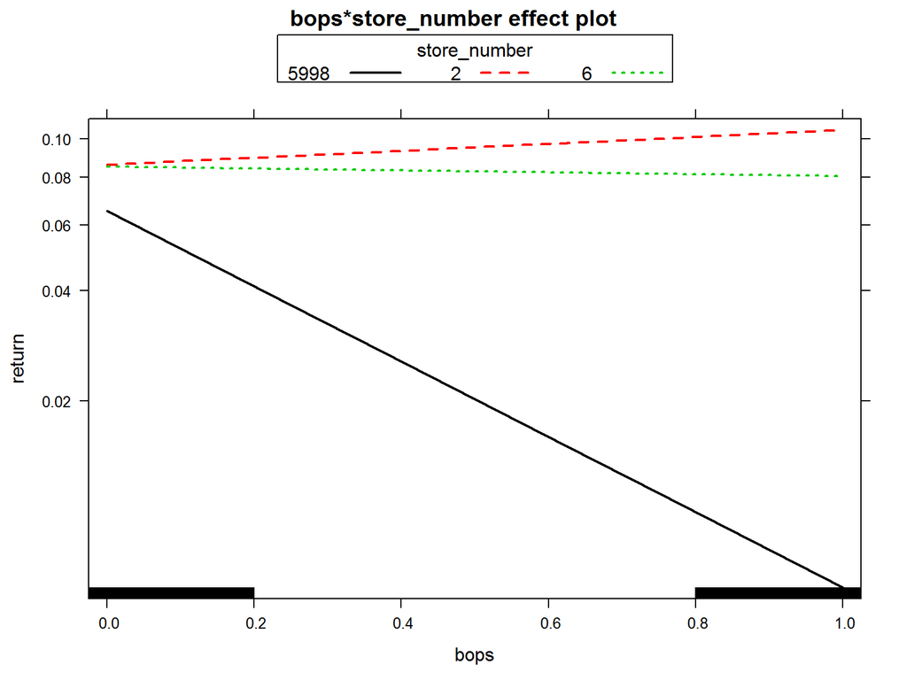